# 3.1 Missingness | ITEMS: Longitudinal Data Analysis

## 3.1 Missingness

Like many longitudinal datasets, the data used in this example contain missingness. When using mixed-effects models, it is important to understand where and how missing observations appear. As we learned in Getting Started, the current data were restricted to children with complete data at the first wave only, though children could appear in the dataset if they were missing data on the second, third, or fourth wave of data collection. To better understand missing data on the outcome, anti-social behavior, we provide examples of four different visualization plots.

### 3.1.1 Setup

Because we plan to analyze our data by *age* and not *wave*, let’s first get a sense of how many anti-social scores are missing at each age level. We know that children were measured up to four times each, but children ranged from ages 6 - 15 in the dataset. Even though we don’t have an anti-social behavior score for each child at each age (6, 7, 8, 9, 10…), we know that *theoretically* each child could have contributed an anti-social behavior score at each age.

Using the `pivot` functions from the `tidyr` package, we can identify missing data at each age for each child:

```r
dat_miss <- dat_long %>%
  dplyr::select(., person_id, child_age, anti_score) %>%
  dplyr::filter(., !is.na(child_age)) %>%
  tidyr::pivot_wider(
    names_from = "child_age",
    values_from = c("anti_score")
  ) %>%
  tidyr::pivot_longer(
    cols = -person_id,
    names_to = "child_age",
    values_to = "anti_score"
  ) %>%
  dplyr::mutate(
    child_age = as.numeric(child_age),
    anti_miss = dplyr::if_else(is.na(anti_score), 1, 0)
  ) %>%
  dplyr::left_join(., dat_long) %>%
  dplyr::select(., person_id, child_age, wave, anti_score, anti_miss) %>%
  dplyr::mutate(., fill_pal = dplyr::case_when(
    !is.na(wave) ~ wave,
    TRUE ~ 4
  )) %>%
  dplyr::arrange(., anti_miss, child_age, person_id) %>%
  print(.)
```

```
## # A tibble: 4,050 x 6
##    person_id child_age  wave anti_score anti_miss fill_pal
##        <dbl>     <dbl> <dbl>      <dbl>     <dbl>    <dbl>
##  1         1         6     0          1         0        0
##  2         5         6     0          2         0        0
##  3         6         6     0          1         0        0
##  4         8         6     0          0         0        0
##  5        11         6     0          1         0        0
##  6        14         6     0          2         0        0
##  7        17         6     0          2         0        0
##  8        23         6     0          0         0        0
##  9        26         6     0          1         0        0
## 10        29         6     0          1         0        0
## # ... with 4,040 more rows
```

### 3.1.2 Lollipop Plot

If children were measured 4 times over 10 possible ages, we could reasonably expect to be missing anti-social behavior scores at a rate of 60% in each age group, assuming that missingness were distributed uniformly and that children were all measured at evenly spaced intervals. Let’s explore this assumption using what is known as a “lollipop plot”. We include a horizontal dashed line to indicate the 60% threshold.

We can also use this plot to highlight places where missingness is much higher (or lower) than what we expect using colors and labels. In plotting, we find that at age 15, about 98% of possible anti-social behavior scores are missing, suggesting that most children didn’t reach age 15 by the end of the study.

#### 3.1.2.1 Code

```r
# helper for axis limits
age_lim <- c(min(dat_long$child_age, na.rm = TRUE),
             max(dat_long$child_age, na.rm = TRUE))

# adjust dat_miss for lollipop plot
dat_lollipop <- dat_miss %>%
  dplyr::group_by(., child_age) %>%
  dplyr::summarise(
    pct_miss = mean(anti_miss, na.rm = TRUE) * 100
  )
# plot
lolli_plot <- dat_lollipop %>%
  ggplot2::ggplot(
    ggplot2::aes(x = child_age, y = pct_miss)
  ) +
  ggplot2::geom_segment(
    ggplot2::aes(x = child_age, xend = child_age, y = 0, yend = pct_miss),
    color = dplyr::if_else(
      dat_lollipop$pct_miss > 95,
      viridis::plasma(n = 4, end = 0.75)[4],
      "gray25"
    ),
    size = dplyr::if_else(dat_lollipop$pct_miss > 95, 1.3, 0.7)
  ) +
  ggplot2::geom_point(
    color = dplyr::if_else(
      dat_lollipop$pct_miss > 95,
      viridis::plasma(n = 4, end = 0.75)[4],
      "gray25"
    ),
    size = dplyr::if_else(dat_lollipop$pct_miss > 95, 5, 2)
  ) +
  ggplot2::geom_text(
    ggplot2::aes(
      x = child_age - 0.5,
      y = pct_miss - 5,
      label = paste0(round(pct_miss, 1), "%")
    ),
    data = dat_lollipop %>% dplyr::filter(pct_miss > 95),
    vjust = 1,
    hjust = 0.5
  ) +
  ggplot2::geom_curve(
    ggplot2::aes(
      x = child_age - 0.5,
      y = pct_miss - 5,
      xend = child_age,
      yend = pct_miss),
    data = dat_lollipop %>% dplyr::filter(pct_miss > 95),
    arrow = ggplot2::arrow(length = ggplot2::unit(0.03, "npc")),
    curvature = -0.5
  ) +
  ggplot2::geom_hline(yintercept = 60, color = "gray50", linetype = "dashed") +
  ggplot2::scale_x_continuous(
    limits = c(age_lim[1] - .5, age_lim[2] + .5),
    breaks = seq(age_lim[1], age_lim[2], 1)
  ) +
  ggplot2::theme(
    legend.position = "none"
  ) +
  ggplot2::xlab("Child Age") +
  ggplot2::ylab("Percent Missing") +
  ggplot2::ggtitle("Percent of Children Missing Anti-Social Scores by Age")
```

#### 3.1.2.2 Printed Plot

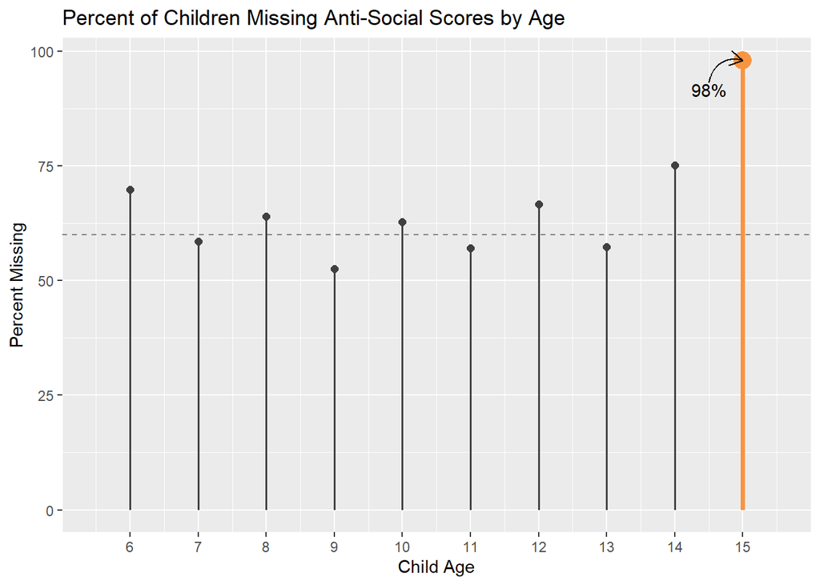

```r
# print lollipop plot
lolli_plot
```

### 3.1.3 Bar Plot by Pattern

Another helpful way to examine missingness in longitudinal data is to look at the *patterns* of missingness. We can think about this like within-person attrition. In other words, for each person, we calculate the percent of measurement waves they participated in out of the possible 4. There are four possible options in our situation (we ignore order to keep the example simple):

1. anti-social data are present for each of the four waves,
2. anti-social data are present for 3 of the four waves (we ignore order, but you could differentiate between individuals who have data for Waves 1, 2, and 3 and individuals who have data for Waves 1, 3, and 4),
3. anti-social data are present for 2 of the four waves (again, we ignore order), and
4. anti-social data are present for 1 wave only (in our case, due to the way our sample was defined, we know that people with only 1 wave of data contributed to the first wave).

#### 3.1.3.1 Code

```r
dat_attrit_l <- dat_miss %>%
  dplyr::group_by(., person_id) %>%
  dplyr::summarise(
    total_waves = sum(1 - anti_miss)
  ) %>%
  dplyr::group_by(., total_waves) %>%
  dplyr::summarise(
    ct_waves = dplyr::n(),
    pct_waves = dplyr::n() / NROW(dat_wide)
  )
```

```r
bar_plot_l <- dat_attrit_l %>%
  ggplot2::ggplot(.) +
  ggplot2::aes(
    x = forcats::fct_reorder(as.factor(total_waves), dplyr::desc(total_waves)),
    y = pct_waves * 100,
    fill = as.factor(total_waves)
  ) +
  ggplot2::geom_bar(stat = "identity") +
  ggplot2::geom_text(
    ggplot2::aes(
      y = pct_waves * 100 + 5,
      label = round(pct_waves * 100, 1)
    ),
    size = 3.5
  ) +
  ggplot2::scale_x_discrete(
    labels = c("4" = "Exactly 4 Waves (All)",
               "3" = "Exactly 3 Waves (Any)",
               "2" = "Exactly 2 Waves (Any)",
               "1" = "Exactly 1 Wave (1st)")
  ) +
  ggplot2::scale_fill_viridis_d(end = 0.75, option = "C") +
  ggplot2::theme(
    legend.position = "none",
    axis.text.x = ggplot2::element_text(
      angle = 45,
      hjust = 1,
      margin = ggplot2::margin(t = 0, r = 0, b = 10, l = 0)
    ),
    axis.text.y = ggplot2::element_text(
      margin = ggplot2::margin(t = 0, r = 0, b = 0, l = 10)
    )
  ) +
  ggplot2::ylim(0, 100) +
  ggplot2::xlab("Number of Data Collection Waves Completed") +
  ggplot2::ylab("Percent of Children \n per Attrition Category") +
  ggplot2::ggtitle(
    expression(
      paste("Attrition Patterns of Anti-Social Behavior Scores ",
            "(", n["Wave 1"], " = 405)")
    )
  )
```

#### 3.1.3.2 Printed Plot

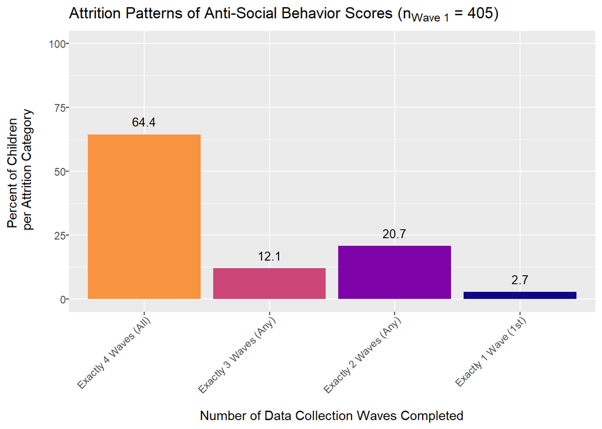

```r
# print bar by pattern plot
bar_plot_l
```

### 3.1.4 Bar Plot by Wave

In this next bar plot example, we display across-person attrition. Here, we are merely interested in what percent of our sample (n = 405) contributed anti-social data at each wave.

#### 3.1.4.1 Code

```r
dat_attrit_c <- dat_miss %>%
  dplyr::filter(., !is.na(wave)) %>%
  dplyr::group_by(., wave) %>%
  dplyr::summarise(
    total_obs = sum(1 - anti_miss),
    pct_obs = sum(1 - anti_miss) / NROW(dat_wide)
  )
```

```r
bar_plot_c <- dat_attrit_c %>%
  ggplot2::ggplot(.) +
  ggplot2::aes(
    x = as.factor(wave),
    y = pct_obs * 100,
    fill = as.factor(total_obs)
  ) +
  ggplot2::geom_bar(
    stat = "identity"
  ) +
  ggplot2::geom_text(
    ggplot2::aes(
      y = pct_obs * 100 + 5,
      label = round(pct_obs * 100, 1)
    ),
    position = ggplot2::position_dodge(width = 0.9),
    size = 3.5
  ) +
  ggplot2::scale_x_discrete(
    labels = c("0" = "Wave 1",
               "1" = "Wave 2",
               "2" = "Wave 3",
               "3" = "Wave 4")
  ) +
  ggplot2::scale_fill_viridis_d(end = 0.75, option = "C") +
  ggplot2::theme(
    legend.position = "none",
    axis.text.x = ggplot2::element_text(
      angle = 45,
      hjust = 1,
      margin = ggplot2::margin(t = 0, r = 0, b = 10, l = 0)
    ),
    axis.text.y = ggplot2::element_text(
      margin = ggplot2::margin(t = 0, r = 0, b = 0, l = 10)
    )
  ) +
  ggplot2::xlab("Measurement Wave") +
  ggplot2::ylab("Percent of Children \n Responding within Each Wave") +
  ggplot2::ggtitle(
    expression(
      paste("Anti-Social Behavior Score Reporting Rates ",
            "(", n["Wave 1"], " = 405)")
    )
  )
```

#### 3.1.4.2 Printed Plot

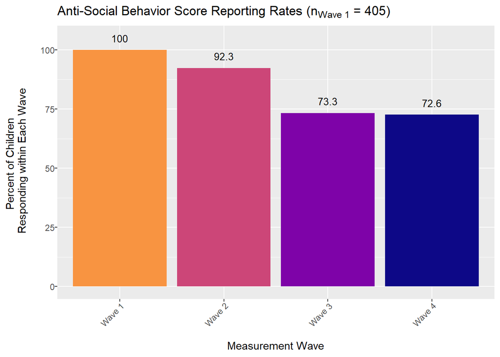

```r
# print bar by wave plot
bar_plot_c
```

### 3.1.5 Raster Plot

This last missingness plot example is called a “raster plot”. Whereas the previous plots provided an aggregated glimpse of missing data in our dataset, the raster plot displays the missingness for each individual in our data. Using color to indicate the measurement wave and carefully ordering the data in the plot, we can make sense of a large amount of data all at once.

#### 3.1.5.1 Code

```r
raster_plot <- dat_miss %>%
  ggplot2::ggplot(.) +
  ggplot2::aes(
    x = child_age,
    y = forcats::fct_inorder(as.factor(person_id)),
    fill = as.factor(fill_pal)
  ) +
  ggplot2::geom_raster(hjust = 0.5, vjust = 0.5) +
  ggplot2::scale_x_continuous(
    limits = c(age_lim[1] - .5, age_lim[2] + .5),
    breaks = seq(age_lim[1], age_lim[2], 1)
  ) +
  ggplot2::scale_fill_manual(
    name = "Wave",
    labels = c("1", "2", "3", "4", "Missing Score"),
    values = c(viridis::viridis(4, option = "C", end = 0.75), "grey90")
  ) +
  ggplot2::theme(
    panel.background = ggplot2::element_blank(),
    panel.grid.minor = ggplot2::element_blank(),
    panel.grid.major = ggplot2::element_blank(),
    axis.text.x = ggplot2::element_blank(),
    axis.ticks.x = ggplot2::element_blank(),
    legend.position = "bottom"
  ) +
  ggplot2::labs(
    x = "Child Age",
    y = "Child ID",
    title = "Missing Anti-Social Scores by Age and Wave"
  ) +
  ggplot2::coord_flip()
```

#### 3.1.5.2 Printed Plot

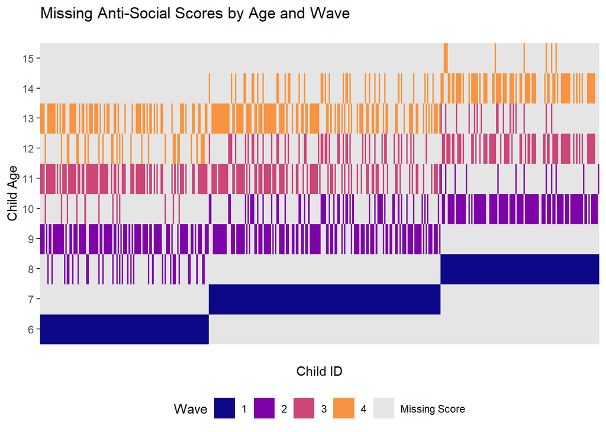

```r
# print raster plot
raster_plot
```

### 3.1.6 Update Dataset

In the step above, we learned that very few children were measured at age 15 (in fact, only 8 children were measured at age 15). For the purposes of this guided example, we will remove those 8 children from the analytic dataset to avoid estimation and convergence issues in modeling later on.

*NOTE: There are better ways to deal with small sample sizes, but those methods are outside the scope of this module. We do not generally recommend deleting observations!*

```r
# find ids for children who are 15 at wave 4
remove_id <- dat_long %>%
  dplyr::filter(., child_age == 15) %>%
  dplyr::select(., person_id) %>%
  unlist(.)

# remove ids identified in remove_id
dat_final <- dat_long %>%
  dplyr::filter(., !(person_id %in% remove_id))

# check new sample size
dat_final %>%
  dplyr::distinct(., person_id) %>%
  NROW(.)
```

```
## [1] 397
```